# Statistik och dataanalys I

# Att sammanfatta numeriska variabler

## Numeriska variabler - hur kan de beskrivas?

- För numeriska variabler används vanligtvis **histogram** istället för stapeldiagram
- Histogram ser ut ungefär som stapeldiagram, men istället för kategorier representerar staplarna intervall av numeriska värden
- Till vänster ser vi ett stapeldiagram för den kategoriska variabeln *Class*
- Till höger ser vi ett histogram för den numeriska variabeln *Age*

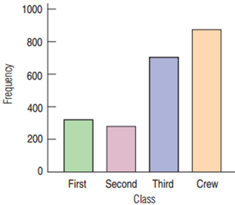

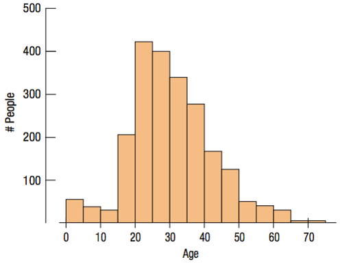

## Histogram

- Varje stapel representerar ett åldersintervall på 5 år
- Vi ser vi att alla passagerare på Titanic var mellan 0 och 75 år gamla
- Den fjärde stapeln från vänster visar att drygt 200 passagerare var 15-19 år

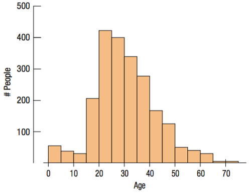

## Histogram

- När du gör ett histogram väljer du själv **bredden** på dina intervall
- I histogrammet till vänster representerar de orangefärdage staplarna ungefär 400 personer vardera
- I det högra histogrammet är de vänstra intervallen ihopslagna, och den sammanslagna stapeln representerar då ungefär 800 personer

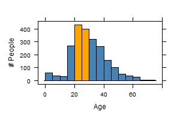

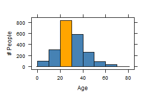

## Histogram med tätheter

- Som alternativ finns även **täthetshistogram** (*density histogram*)
- I ett tätnhetshistogram motsvarar **arean** av en stapel andelen observationer som ligger inom motsvarande intervall
- **Exempel**:
  - Den högsta stapeln i den högra figuren har en höjd som är $\approx 0.036$
  - Stapeln är 10 år bred, så arean är $0.036 \cdot 10 = 0.36$, och andelen personer i åldersintervallet 20-29 år var alltså ungefär 36%

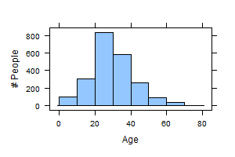

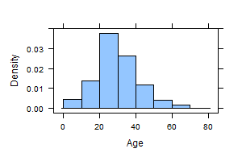

## Andra typer av diagram för numeriska variabler

- Det finns även stam- och bladdiagram (överst till vänster), punktdiagram (överst till höger) och täthetdiagram (underst)
- Täthetsdiagrammet har samma form som ett histogram, men är utjämnat

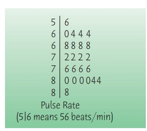

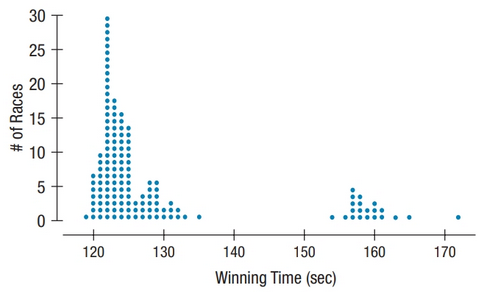

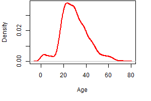

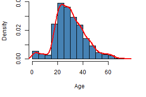

## Att analysera histogram

- Formen på ett histogram kan ge oss intressant information om hur värden på en variabel är fördelade
- Vi kan titta på
  - **Typvärdet** (*en: mode*) är det värde av en variabel som observerats flest gånger (det värde på x-axeln där fördelningskurvan når sin topp)
  - **Symmetrin och skevheten** (*en: symmetry/skewness*) anger om fördelningen är symmetrisk eller sned
  - **Extrema värden (outliers)** är observationer som ligger långt från övriga observationer

## Typvärde

- Om fördelningen av en variabel har en enda topp så hittar vi typvärdet där. En sådan fördelning är **unimodal** (one mode)
- Figuren nedan visar fördelningen magnituden på jordbävningar, och har sitt typvärde i närheten av 7

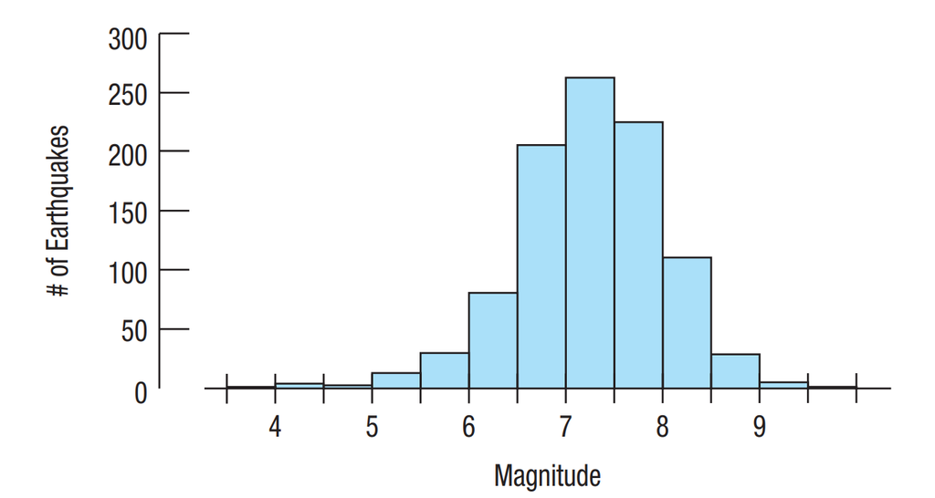

## Typvärde

- Om en fördelning har två toppar kallas den **bimodal**, och om den har flera toppar kallas den **multimodal**
- Figuren till vänster visar ett index för levnadskostnader i olika städer, och har en topp var vid 40 och 80 (bimodal, kanske två olika grupper av städer?)
- En fördelning som är jämn utan tydliga toppar och dalar, som den till höger, kallas för en **uniform** eller **likformig fördelning**

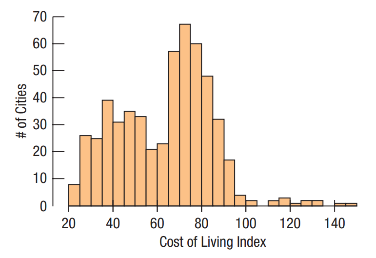

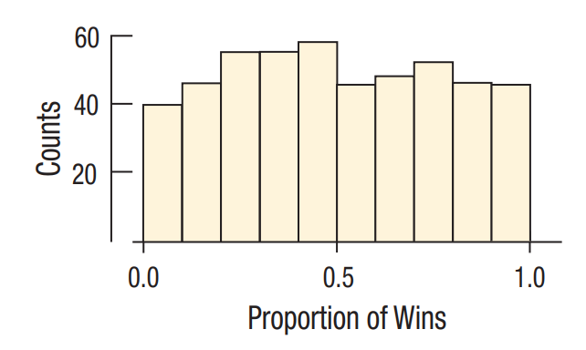

## Symmetri

- Vi säger attt det **gröna** histogrammet är **symmetriskt**
- Den högra halvan av histogrammet är ungefär en spegelbild av den vänstra
- Denna egenskap är förvånanstvärt vanlig i naturen

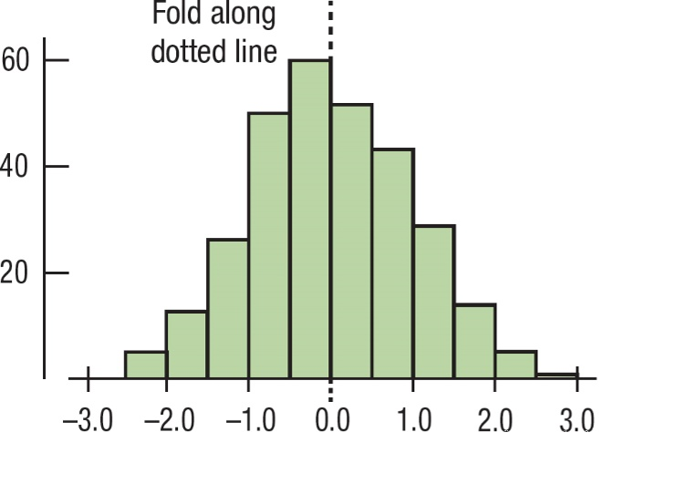

## Symmetri och skevhet

- Det **lila** histogrammet visar hur mycket kvinnliga hjärtpatienter har fakturerats för vårdbehandling
- Histogrammet är **skevt åt höger** (*right skewed*) – många patienter har betalat långt mer än typvärdet, medan få har betalat mycket mindre
- Vi säger skevt åt **höger** eftersom **högersvansen är utdragen**

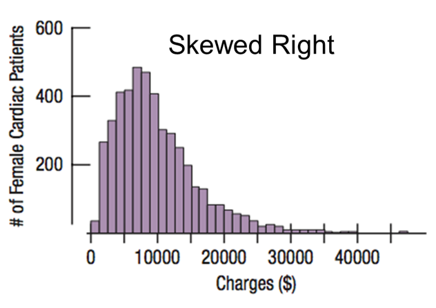

## Symmetri och skevhet

- Det **blå** histrogrammet visar åldern hos kvinnliga hjärtpatienter
- Histogrammet är **skevt åt vänster** (*left skewed*) – många patienter har en ålder långt under typvärdet, men få har en ålder långt över
- Vi säger skevt åt **vänster** eftersom **vänstersvansen är utdragen**

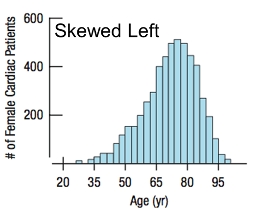

## Outliers

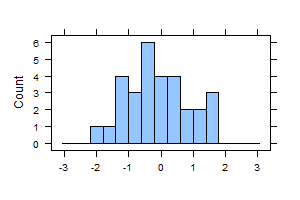

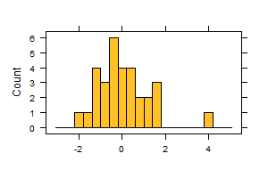

- Extrema värden som avviker från övriga observationer brukar kallas för **outliers**, även på svenska
- Det blå histogrammet nedan har inga outliers – alla observationer ligger samlade nära varandra
- Det gula histogrammet har en outlier till höger om de övriga observationerna

## Outliers

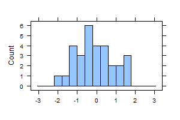

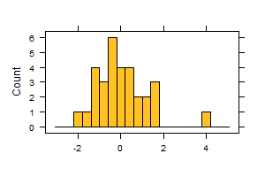

- Outliers kan få stora effekter i en statistisk analys, och behöver ofta utredas
- Outliers kan vara resultat av misstag (i mätning, inmatning, etc), men kan också vara korrekta observationer
- Om outliers tas bort ur datamaterialet måste detta dokumenteras och motiveras

## Fördelningens centrum

- Vi vill ofta ha ett mått på det typiska värdet av en variabel, vanligtvis ett värde vid fördelningens centrum
  - I en symmetrisk fördelning finns det typiska värdet i mitten
  - I en skev fördelning är det lite svårare att ange ett rimligt typiskt värde
- Vi tar upp tre mått som alla beskriver någon sorts centrum för fördelningen: **typvärde** (*mode*), **medelvärde** (*mean*), och **median**

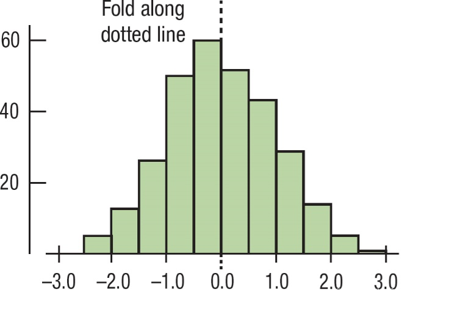

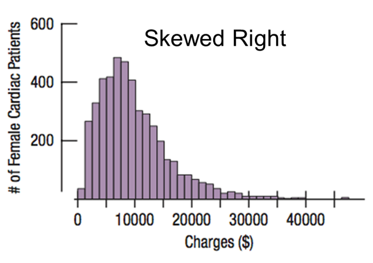

## Medelvärde (mean)

- Anta att vi har 7 observationer av en variabel som vi kallar $x$:

$$x_1=12, x_2=11, x_3=9, x_4=13, x_5=12, x_6=10, x_7=11$$

- Medelvärdet av de här observationerna är

$$\cfrac{12+11+9+13+12+10+11}{7} = 11.14$$

- Mer allmänt kan vi säga att medelvärdet för $n$ observationer beräknas som

$$\bar x = \cfrac{x_1 + x_2 + \ldots + x_n}{n} = \cfrac{\sum_{i=1}^n x_i}{n}$$

## Medelvärde

- Låt oss förklara notationen i uttrycket

$$\bar x = \frac{\sum_{i=1}^n x_i}{n},$$

- $\bar x$ (*uttalas x-streck eller x-bar*) betecknar medelvärdet för variabeln $x$, och motsvarande gäller för $\bar y$ osv
- $n$ används som symbol för antalet observationer i våra data (i föregående exempel har vi $n = 7$)
- $\sum_{i=1}^n x_i$ betecknar summan av alla värden av variabeln $x$, dvs
  $$\sum_{i=1}^n x_i = x_1+x_2+x_3+...+x_n$$

## Median

- Medianen är ett värde som är större än ungefär hälften av observationerna och mindre än ungefär hälften av observationerna
- Vi säger *ungefär* då antalet observationer inte alltid är jämnt delbart med 2
- Figuren visar åldersfördelningen för Titanics besättning
- Vi antar att de **blå** staplarna motsvarar lika många personer som de i **beige**
- Vi har då lika många över som under 30 år, och medianåldern är ca 30

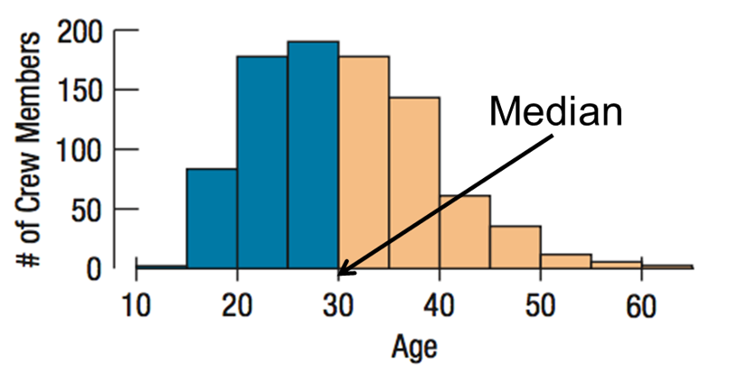

## Median

Vi hittar medianen på följande sätt:

1. Sortera observationerna från lägsta till högsta värde
2. Ta fram medianen enligt nedan
   - **Om antalet observationer är udda:** hitta den mittersta observationen, och ange värdet på denna median
   - **Om antalet observationer är jämnt:** identifiera de **två** observationerna som ligger i mitten, och ange deras **medelvärde** som median

## Median med udda antal observationer

Vi har variabeln $x$ med följande 5 värden:

| x |  |  |  |  |
| --- | --- | --- | --- | --- |
| 14.7 | 2.2 | 1.7 | 3.09 | 3.11 |

Vi börjar med att sortera våra värden i storleksordning

| x |  |  |  |  |
| --- | --- | --- | --- | --- |
| 1.7 | 2.2 | 3.09 | 3.11 | 14.7 |

## Median med udda antal observationer

Vi har variabeln $x$ med följande 5 värden:

| x |  |  |  |  |
| --- | --- | --- | --- | --- |
| 14.7 | 2.2 | 1.7 | 3.09 | 3.11 |

Medianen är värdet i mitten av den sorterade listan

| x |  |  |  |  |
| --- | --- | --- | --- | --- |
| 1.7 | 2.2 | 3.09 | 3.11 | 14.7 |

Medianen är alltså **3.09**

## Median med jämnt antal observationer

Vi har variabeln $x$ med följande 6 värden:

| x |  |  |  |  |  |
| --- | --- | --- | --- | --- | --- |
| 14.7 | 2.2 | 1.7 | 3.09 | 3.11 | 16.3 |

Vi börjar med att sortera våra värden i storleksordning

| x |  |  |  |  |  |
| --- | --- | --- | --- | --- | --- |
| 1.7 | 2.2 | 3.09 | 3.11 | 14.7 | 16.3 |

## Median med jämnt antal observationer

Vi har variabeln $x$ med följande 6 värden:

| x |  |  |  |  |  |
| --- | --- | --- | --- | --- | --- |
| 14.7 | 2.2 | 1.7 | 3.09 | 3.11 | 16.3 |

Medianen är medelvärdet av de två observationerna i mitten

| x |  |  |  |  |  |
| --- | --- | --- | --- | --- | --- |
| 1.7 | 2.2 | 3.09 | 3.11 | 14.7 | 16.3 |

Medianen är alltså
$$\frac{3.09+3.11}{2} = 3.10$$

## Median, medelvärde eller typvärde?

- I en symmetrisk fördelning (bild till vänster) är de tre måtten oftast snarlika
- I en skev fördelning (bild till höger) påverkas medelvärdet mer av värden ute i svansarna
- Outliers kan ha stor påverkan på medelvärdet, men inte på medianen

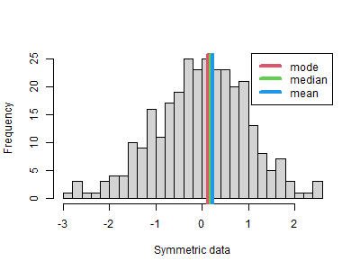

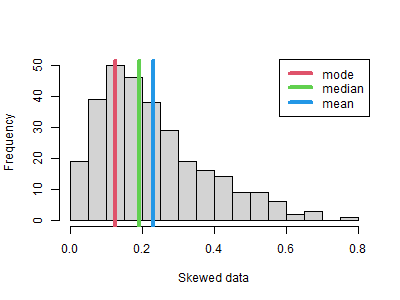

## Median, medelvärde eller typvärde?

- Vilket värde som bör rapporteras beror på syftet
- Om du säljer biljetter till en båtresa och vill veta hur stora intäkterna blir är du förmodligen intresserad av medelvärdet av biljettpriset
- En köpare som undrar vad en typisk biljett kostar är kanske mer intresserad av medianpriset, som inte påverkas av priset på de allra dyraste biljetterna

## Fördelningens spridning

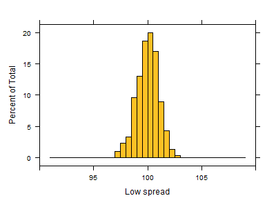

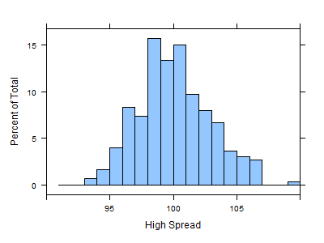

- Fördelningarna har ungefär samma medelvärde, men olika **spridning**
- Om histogrammen visar inkomstfördelningen i två länder så representerar
  - Det **gula** ett land där inkomstnivåerna är relativt lika
  - Det **blå** ett land där skillnaderna i inkomst är större

## Fördelningens spridning

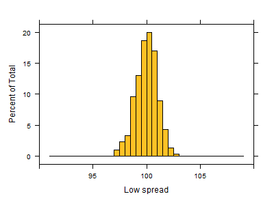

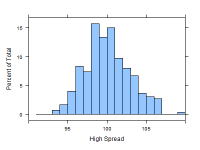

- Det finns olika mått på hur stor spridningen är, till exempel
  - Variationsbredd (range)
  - Standardavvikelse (standard deviation)
  - Kvartilavstånd (interquartile range)

## Variationsbredd

- **Variationsbredden** mäter avståndet mellan den största och den minsta observationen
- Variationsbredden påverkas kraftigt av outliers

**Exempel:**

- Bland Titanics besättningsmän var den äldsta 62 år och den yngsta 14 år
- Variationsbredden för åldersvariabeln är avståndet mellan 62 och 14, alltså
  $$62 − 14 = 48$$

## Standardavvikelse

- **Standardavvikelsen** (betecknas $s$) mäter hur mycket observationerna avviker från medelvärdet
- För att hitta $s$ är det lättast att först beräkna **variansen** ($s^2$),

$$s^2 = \cfrac{\sum_{i=1}^n(y_i - \bar{y})^2}{n-1}$$

- Standardavvikelsen ges sedan av kvadratroten ur variansen, alltså

$$s = \sqrt{s^2}$$

## Standardavvikelse

- Låt oss förklara notationen

$$s^2 = \cfrac{\sum_{i=1}^n(y_i - \bar{y})^2}{n-1}$$

- Uttrycket $(y_i - \bar{y})^2$ är den kvadrerade skillnaden mellan observationen $y_i$ och medelvärdet av $y$ (alltså $\bar y$)
- Uttrycket $\sum_{i=1}^n(y_i - \bar{y})^2$ är summan av dessa kvadrerade skillnader

$$\sum_{i=1}^n(y_i - \bar{y})^2 = (y_1 - \bar y)^2 + (y_2 - \bar y)^2 + ... + (y_n - \bar y)^2$$

- $y_n$ är vår sista observation

## Beräkning av standardavvikelse

- Antag att vi har mätt vikten (i kg) på nio säckar med jord

| $y_1$ | $y_2$ | $y_3$ | $y_4$ | $y_5$ | $y_6$ | $y_7$ | $y_8$ | $y_9$ |
| --- | --- | --- | --- | --- | --- | --- | --- | --- |
| 23 | 27 | 22 | 11 | 18 | 26 | 19 | 13 | 28 |

- $y_1$ är vikten för första säcken, $y_2$ är vikten för andra säcken, osv
- Som mått på hur mycket vikten skiljer sig åt mellan säckarna vill vi räkna ut standardavvikelsen
- Vi börjar med formeln för variansen

$$s^2 = \cfrac{\sum_{i=1}^n(y_i - \bar{y})^2}{n-1}$$

## Beräkning av standardavvikelse

- Antag att vi har mätt vikten (i kg) på nio säckar med jord

| $y_1$ | $y_2$ | $y_3$ | $y_4$ | $y_5$ | $y_6$ | $y_7$ | $y_8$ | $y_9$ |
| --- | --- | --- | --- | --- | --- | --- | --- | --- |
| 23 | 27 | 22 | 11 | 18 | 26 | 19 | 13 | 28 |

- För att hitta variansen behöver vi säckarnas medelvikt, som ges av
  $$\bar y = \frac{\sum_{i = 1}^n y_i}{n} = \frac{23+27+22+11+18+26+19+13+28}{9} = 20.78$$
- Vi stoppar in värdet i variansformeln, och får

$$s^2 = \cfrac{\sum_{i=1}^n(y_i - 20.78)^2}{n-1}$$

## Beräkning av standardavvikelse

- Antag att vi har mätt vikten (i kg) på nio säckar med jord

| $y_1$ | $y_2$ | $y_3$ | $y_4$ | $y_5$ | $y_6$ | $y_7$ | $y_8$ | $y_9$ |
| --- | --- | --- | --- | --- | --- | --- | --- | --- |
| 23 | 27 | 22 | 11 | 18 | 26 | 19 | 13 | 28 |

- Nästa steg är att beräkna de kvadrerade avvikelserna
  $$(y_1 - 20.78)^2 = (23 - 20.78)^2 = 4.93 \\
  (y_2 - 20.78)^2 = (27 - 20.78)^2 = 38.69 \\
  \vdots \\
  (y_{8} - 20.78)^2 = (13 - 20.78)^2 = 60.53 \\
  (y_9 - 20.78)^2 = (28 - 20.78)^2 = 52.13$$

## Beräkning av standardavvikelse

- Antag att vi har mätt vikten (i kg) på nio säckar med jord

| $y_1$ | $y_2$ | $y_3$ | $y_4$ | $y_5$ | $y_6$ | $y_7$ | $y_8$ | $y_9$ |
| --- | --- | --- | --- | --- | --- | --- | --- | --- |
| 23 | 27 | 22 | 11 | 18 | 26 | 19 | 13 | 28 |

- Summan $\sum_{i=1}^9 (y_i - 20.78)^2$ blir

$$4.93+38.69+1.49+95.65+7.73+27.25+3.17+60.53+52.13 = 291.57$$

- Vi stoppar in detta i formeln och får variansen

$$s^2 = \cfrac{\sum_{i=1}^9 (y_i - 20.78)^2}{n-1} = \cfrac{291.57}{9-1} = 36.446$$

## Beräkning av standardavvikelse

- Antag att vi har mätt vikten (i kg) på nio säckar med jord

| $y_1$ | $y_2$ | $y_3$ | $y_4$ | $y_5$ | $y_6$ | $y_7$ | $y_8$ | $y_9$ |
| --- | --- | --- | --- | --- | --- | --- | --- | --- |
| 23 | 27 | 22 | 11 | 18 | 26 | 19 | 13 | 28 |

- Till slut har vi att standardavvikelsen är

$$s = \sqrt{s^2} = \sqrt{36.446} = 6.037$$

- Vi har att **standardavvikelsen för vikten på jordsäckarna är 6.037 kg**

## Kvartiler och Kvartilavstånd

- **$Q_1$:** är ett värde som är större än 25% av observationerna och mindre än de övriga 75% av observationerna.
- **$Q_2$:** är ett värde som är större än 50% av observationerna och mindre än de övriga 50% av observationerna ($Q_2$ är samma sak som medianen!)
- **$Q_3$:** är ett värde som är större än 75% av observationerna och mindre än de övriga 25% av observationerna.

## Kvartiler och Kvartilavstånd

Det finns ingen entydig regel för hur kvartilerna räknas ut. I De Veaux et al (2021) föreslås följande metod:

1. Sortera observationerna i storleksordning
2. Identifiera medianen, som är samma sak som $Q_2$
   1. Om **antalet observationer är jämnt**: dela in observationerna i två lika stora delar, en med mindre värden och en med större värden (än $Q_2$)
   2. Om **antalet observationer är udda**: gör samma sak som ovan, men låt observationen i mitten ingå i *båda delarna*
3. Räkna ut medianen för observationerna med mindre värden, detta är $Q_1$
4. Räkna ut medianen för observationerna med större värden, detta är $Q_3$

## Kvartiler och percentiler

- Vi kan också tala mer generellt om **percentiler**
- Den *p:te* percentilen är ett värde som är större än *p* procent av observationerna och mindre än *100 - p* procent av observationerna
- **Exempel:** Den 90:e percentilen är ett värde som är större än 90 procent av observationerna och mindre än 10 procent av observationerna
- $Q_1$ är alltså samma sak som den 25:e percentilen, $Q_2$ är samma sak som den 50:e percentilen och $Q_3$ är samma sak som den 75:e percentilen

## Standardavvikelse eller IQR

- Om spridningen i en fördelning bäst rapporteras i form av standardavvikelse eller i form av IQR beror på syftet
- Standardavvikelsen är bättre om det är viktigt att alla observationer beaktas
- IQR är bättre om vi vill ha ett mått som inte påverkas av outliers
- Standardavvikelse brukar rapporteras tillsammans med medelvärdet och IQR tillsammans med medianen

# Statistisk programmering med hjälp av R

## Funktioner i R – Frekvenstabeller

`R`-koden nedan skapar en frekvenstabell som visar hur många passagerare som reste i varje klass på Titanic

```r
#Make a frequency table of variable Class
tally(~Class, data=titanic) # Requires the package mosaic
```

```
Class
   1    2    3 Crew
 324  285  710  889
```

För att köra koden ovan måste vi ha

- Importerat datamaterialet `titanic` till `R`
- Installerat paketet `mosaic`, som innehåller funktionen `tally()`

## Funktioner i R – Stapeldiagram

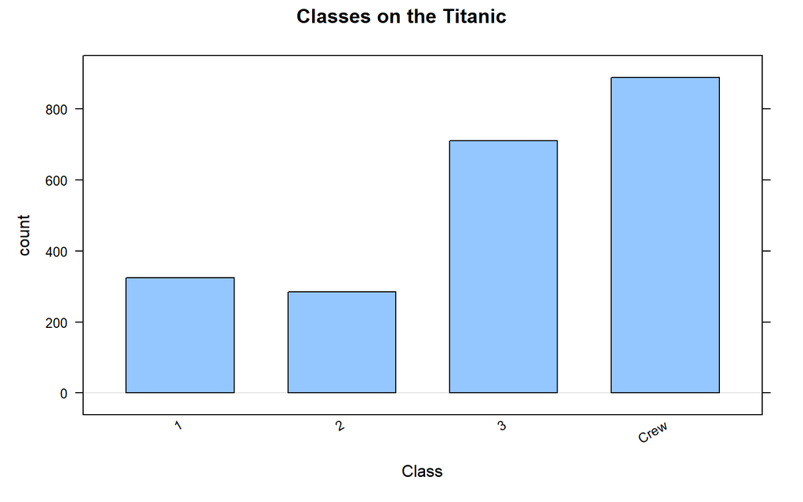

```r
#Make a barplot of variable the variable Class
bargraph(~Class, data=titanic, main="Classes on the Titanic")
```

## Funktioner i R – Pajdiagram

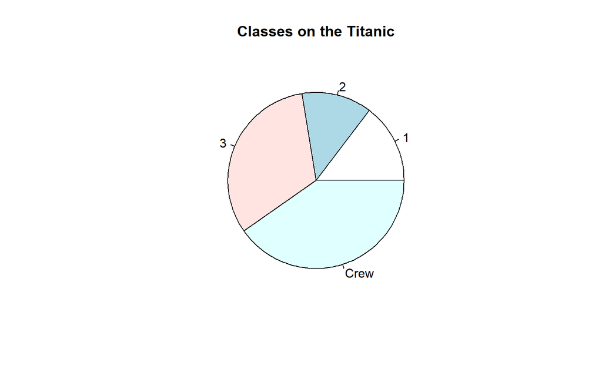

```r
#Make a pie chart of the variable class
class_table <- tally(~Class, data=titanic) # Create freq. table

# Create pie chart using freq. table
pie(x=class_table, main="Classes on the Titanic")
```

## Funktioner i R – Täthetshistogram

Det här kommandot ger oss ett **täthetshistogram**

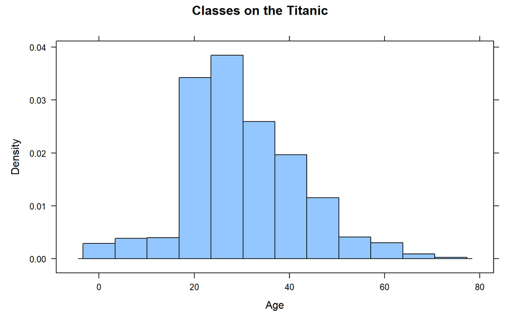

```r
histogram(~Age, data=titanic, main="Classes on the Titanic")
```

## Funktioner i R – Histogram

Genom att sätta `type="count"` får vi ett histogram med frekvenser.

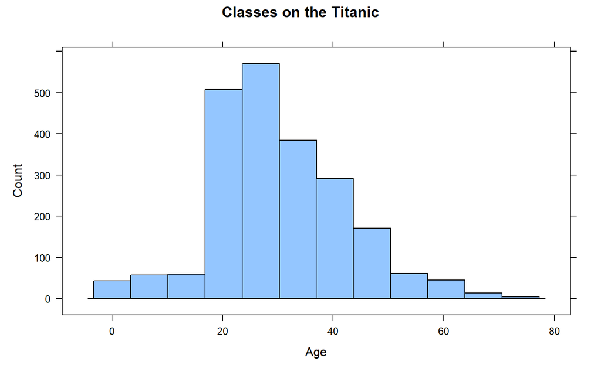

```r
histogram(~Age, data=titanic, main="Classes on the Titanic",
          type="count")
```

## Funktioner i R – Deskriptiva mått

Funktionen `favstats()` i mosaic ger oss flera mått som kan användas för att visa centrum och spridning i en fördelning

Längt till höger ser vi att **missing** har värdet tre, vilket betyder att tre av observationerna saknar värden för variabeln *Age*

```r
favstats(~Age, data=titanic)
```

```
  min Q1 median Q3 max     mean       sd    n missing
 0.08 22     29 37  74 30.14689 11.97386 2205       3
```

## Credits

Dessa slides skapades av Karl Sigfrid för kursen Statistik och Dataanalys I och har uppdaterats av Oskar Gustafsson och Valentin Zulj